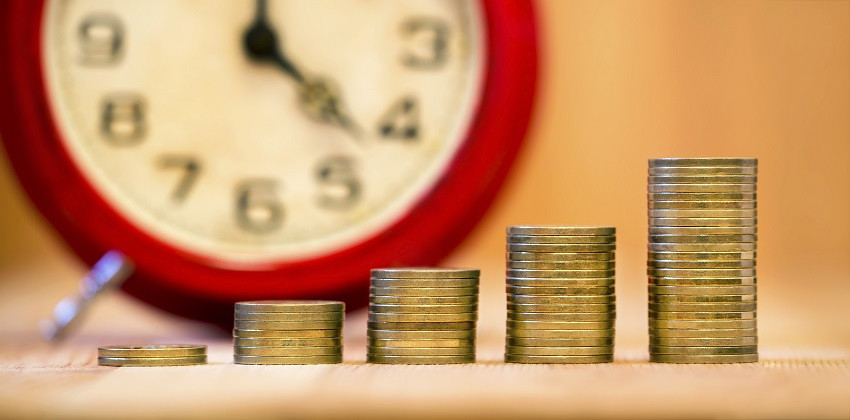

# Introducción a las Matemáticas Financieras

Después de haber estudiado en las entradas anteriores de este blog el tema de las pruebas de hipótesis estadísticas, me ha parecido bien empezar a hablar de un tema que, aunque no sea cercano, está bastante relacionado con la estadística: la matemática financiera. Esto no significa que no vaya a seguir tratando las pruebas estadísticas. Las finanzas son una disciplina que estudia cómo asignar recursos escasos a través del tiempo en condiciones de incertidumbre. Los tres pilares analíticos de las finanzas son:

- El valor del dinero en el tiempo
- La valuación de activos
- La administración del riesgo

El estudio de estos temas es de suma importancia para diversos sectores de la industria y el gobierno, en los que la teoría del interés, la gestión de riesgo y la planeación financiera juegan un papel crucial (por ejemplo, en los seguros, pensiones y tarifas) y requieren, por tanto, de servicios de actuaría y consultoría. Esta rama de las matemáticas es sumamente extensa e imposible de abarcar por completo incluso en este blog, pero al menos intentaré explicar algunos conceptos clave que me parecen interesantes. Empezaré por los conceptos básicos que todos debemos conocer y entender para nuestra vida diaria. Las herramientas matemáticas involucradas directamente en el cálculo de algunas de las fórmulas presentes en estos conceptos son fáciles de entender e incluso sencillas de determinar por medios computacionales, por lo que invito al lector a ponerlos en práctica. Por ahora, solo hablaré de la teoría del interés, que trata el valor del dinero en el tiempo.

## El Valor del Dinero en el Tiempo

Llamamos **préstamo** al acto en el que un ente natural o jurídico, al que llamaremos **acreedor** (o inversionista), presta o cede un bien de capital a otro ente, al que llamaremos **deudor** (o emisor). En la gran mayoría de los casos, esto se hace a cambio de que el deudor, además del valor del bien de capital que fue prestado en un principio (cuya devolución dependerá de las condiciones en las que se haya establecido el préstamo), entregue un beneficio extra (normalmente en porcentaje) al del valor del capital inicial y que además de depender de este dependerá también del tiempo. Dicho beneficio se conoce como **interés**.

Una pregunta que todos en algún momento de nuestras vidas nos hemos hecho es ¿por qué existen los intereses? La respuesta a esta pregunta tiene que ver con el tema de partida en matemática financiera, que es *el valor del dinero en el tiempo*. En las finanzas modernas se considera que dentro de una economía de mercado (es decir, en un mercado donde los precios se establecen por la acción libre de la oferta y demanda de bienes y servicios), además de a los bienes o factores de capital, como la base de la riqueza, el tiempo también es crucial. Esto se debe a una serie de razones, de las cuales he decidido revisar las tres más importantes:

- **La inflación o pérdida de valor de l dinero en el tiempo:** Su efecto más inmediato es la subida generalizada de los precios o la pérdida de poder adquisitivo del dinero.
- **El costo de oportunidad:** El capital invertido en préstamos siempre presenta un costo en el sentido de que dicha riqueza podría haber sido invertida en otros activos materiales, humanos o proyectos que no solo podrían proteger de la inflación sino además ser potencialmente más útiles o rentables. Esto último está vinculado al *riesgo* inherente que corre el prestamista o inversor.
- **La preferencia temporal:** Se refiere al aspecto humano que nos hace preferir las utilidades inmediatas a las futuras, querer comprar lo que se puede hoy a lo que se podría conseguir mañana. Para invertir es necesario ahorrar, lo cual siempre implica abstenerse del consumo presente o de las ya mencionadas utilidades inmediatas, siempre buscando aumentar la riqueza a futuro.

Estos tres factores son igualmente importantes. Incluso si la inflación no existiera, *el valor del dinero en el futuro es menor al del presente* debido al costo de oportunidad vinculado al riesgo y a la preferencia temporal. Hablando de la inflación, cuando se dice que esta disminuye el “valor del dinero”, nos referimos al poder adquisitivo, es decir, a cuántos productos y servicios puedo comprar con una cantidad determinada de dinero. Por ello, no se pierde nada en estudiar cuáles pueden llegar a ser las tres causas lógicas de la inflación. Aquí un pequeño resumen de cada una:

- **La inflación por demanda:** Ocurre cuando la capacidad monetaria de una población aumenta demasiado y resulta ser excesiva e imposible de cubrir por la oferta de bienes y servicios. El resultado de esto es que los precios suben y se ajustan al aumento de capacidad monetaria en la economía. Una de las muchas causas posibles de este tipo de inflación es el aumento del crédito por parte de los bancos comerciales o la disminución de los tipos de interés por parte del banco central. Ejemplos históricos de esto son los Estados Unidos de la postguerra y China en la última década.
- **La inflación de costos:** Sucede cuando la producción vinculada a la oferta se encarece o disminuye. Lo más común es que se produzca cuando se reduce o elimina el acceso a una materia prima o cuando se reduce la mano de obra vinculada a un sector productivo. Un ejemplo anecdótico de lo primero es la crisis del petróleo en Estados Unidos de $1973$ a $1974$ debido al embargo de esta materia prima por parte de la OPEP.
- **Expansión monetaria:** Esta es la más común y sucede cuando un país expande la emisión de dinero, normalmente como medida para intentar contrarrestar el déficit o pérdida fiscal (el déficit fiscal es la diferencia entre los altos gastos y bajos ingresos del estado). El caso más reconocible para los lectores es la hiperinflación sucedida en Venezuela en el periodo de 2016 a 2022, aunque este periodo sigue en discusión, que se debió a la expansión monetaria del banco central de Venezuela, el BCV.

Estimar la inflación es un proceso que requiere de modelos de análisis de series de tiempo y mediciones poblacionales macroeconómicas, que tal vez toque a futuro. Por ahora, nos basta con saber qué es la inflación y cuáles son sus tipos.

Volviendo al **interés**, este se puede entender entonces simplemente como la medida del valor del dinero en el tiempo $I$ resultado de restar el valor del capital inicial (o presente) $\text{P}$ del capital resultante (o futuro) $\text{F}$:

$$I=\text{F}-\text{P}$$

### Tasa de Interés

Normalmente, en vez de tratar con el interés en montos de ganancia fijos para cada caso, lo que se suele hacer es expresarlo en términos de un *porcentaje* con respecto al valor de la inversión. Dicho porcentaje se conoce como **tasa de interés** y normalmente se denota con $i$ y es igual a la razón entre la ganancia de los intereses $I$ y la cantidad original invertida $\text{P}$, es decir:

$$i=\frac{\text{F}-\text{P}}{\text{P}}=\frac{I}{P}$$

Nótese que la estructura $\frac{x_1-x_0}{x_0}$ corresponde a la **medición de un cambio relativo**, que es sumamente importante en todas las disciplinas prácticas que utilizan modelos matemáticos, por su relación con las derivadas y la medición de los *cambios*. Probablemente hable de ello en un futuro anexo. De dicha ecuación se puede deducir la fórmula para determinar la renta del interés por medio de su tasa:

$$I=\text{P}\times i$$

Tanto el interés como su tasa se estudian con respecto a un periodo de tiempo determinado, lo cual implica que podremos trabajar con el interés por medio de funciones con respecto al tiempo (función de acumulación) como veremos más adelante. Una conclusión importante del estudio del interés es que dos valores diferentes en distintas fechas pueden llegar a considerarse **equivalentes**. Un valor presente $P_0$ es equivalente a un valor futuro $\text{F}_0$ si el valor futuro cubre el valor presente más los intereses a la tasa exigida por el inversionista.

Claro que aún nos queda hablar prácticamente de toda la teoría del interés. En el siguiente artículo en el que trate dicho tema, hablaré de la función de acumulación, el interés simple, compuesto y el valor presente. Con esto abrimos una nueva rama de las aplicaciones de la matemática al mundo real, además de la estadística, la matemática financiera (a pesar de que estas dos estén íntimamente relacionadas). Espero que esto ayude a refrescar no solo a los lectores, sino también a mí. También debo aclarar que elegí este tema (y no métodos de aproximación y medidas para experimentos) por la importancia que tiene en la vida de las personas comunes. Alguien puede vivir de forma relativamente normal sin saber cómo se determina si una medida atípica en un acelerador de partículas prueba un modelo cuántico o es solo una casualidad. Pero no va a ser responsable en sus finanzas y en su vida si no sabe cómo funcionan los intereses o el cómo y por qué de la inflación. Estamos viviendo un fenómeno en el cual la educación matemática y financiera está siendo cada vez menor entre la población, como muestran las pruebas PISA, y si puedo aportar mi granito de arena para prevenir esa situación, lo haré con gusto.

## Referencias

- Kozikowski Zarska, Z. (2007). *Matemáticas financieras: El valor del dinero en el tiempo*. McGraw-Hill.
- Meza Orozco, Juan de Jesús (2011). *Matemáticas financieras aplicadas: Uso de las calculadoras financieras y Excel* (4ta Ed.). ECOE Ediciones.